# Study Findings on Marketing Campaigns

Jordan Gropper

# The Data

- We were given 52 weeks worth of data from dozens of stores across the country, observing 21,000 different product purchases under different conditions.
  - We analyzed small advertisement campaigns (ad B), medium advertisement campaigns (ad A) and a promotions and their impact on sales and revenue.
  - We compared our findings with our competition, Kelloggs and Post, checking sales trends across the industry.
  - We found two specific ways to improve our marketing and potentially increase revenue.
- Some fast facts about the company and our sales.
  - We sold 187,450 units of cereal during the 52 week period with the data we were given. That is an average of 3,604 sales per week.
  - From those sales we made $677,616.60 in revenue. This brings us to an average of $3.61 revenue per units sold.
  - Despite this good news we did end the year with a decline in sales units per week. We are going to take a look at what may have caused this to occur.
  - *Median is the measurement of the most middle value in the range of revenue that we have, in this case it is more reliable than just the average.

# **Finding 1:** General Mills’ Small Ad Campaign

```
- When not using promotions, the Small Ad campaigns outsell the medium campaigns.
```

- If a store is not able to also offer a promotion alongside the advertisement campaign, then the small campaigns are the best choice.
  - When doing statistical tests to check for consistency across the entire company we found that the Small Campaigns actually slightly out perform the Medium ones, selling 10 median units versus 9 median units.
  - Assuming that a medium sized campaign would cost more to launch, without a promotion it is best to just use small ad campaigns.

[figure not shown]

# **Finding 2:** Focus in on promotion stores that do the best

```
- Advice: Mimic store numbers 230514, 233072, 240824, 241553 & 243941
```

- We analyzed the data set to find the store that did the best sales of median units when it was promoting.
  - We have done this to determine which stores are doing the best when they are promoting items in the hopes to find how to improve the promotion abilities of the company nation wide.
  - These stores each sold a Median of 28 units per promotion of their top brand compared to the company wide median of 10.
  - If we are able to increase our promotions by mimicing these five stores we may be able to double or even triple the current amount of promoted units we sell.
  - This is crucial because some of our promotions discount the price up to 25%, meaning that we would have to seel 4 units to break even with the discount.
  - Using promotions is definitely in our faovr as without promotions we sell 6 units compared to the current median units we sell which is 10.

    Top brands of cereal sold at the top 5 stores

    | Store Number | Best Brand | Median Units Sold |
    | --- | --- | --- |
    | 230514 | Lucky Charms | 28 |
    | 233072 | Cinnamon Toast Crunch | 28 |
    | 240824 | Lucky Charms | 28 |
    | 241553 | Cinnamon Toast Crunch | 28 |
    | 243941 | Cocoa Puffs | 28 |

# What Does It Look Like?

+Combining small advertisements With promotions

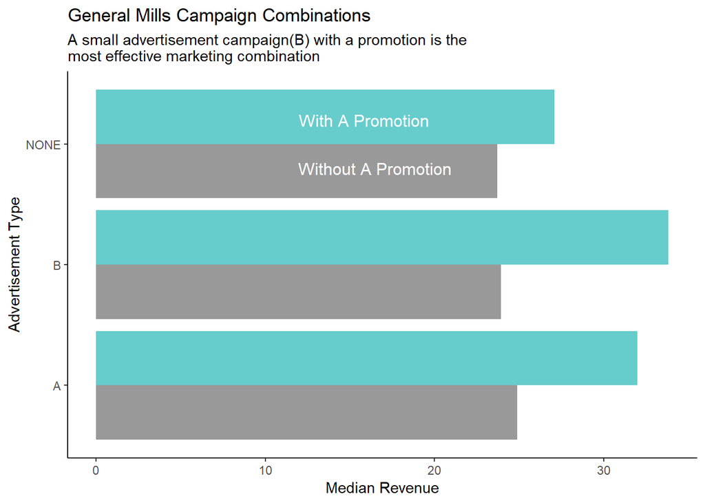

# Decreasing Sales Trends

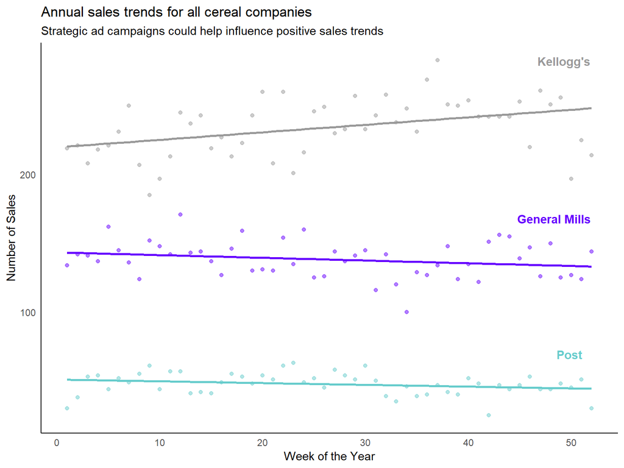